# StarHotelSolution

## Model evaluation criterion

## Model can make wrong predictions as:

- Predicting the guest is not going to cancel but in reality the guest is cancelling the booking.
- Predicting the guest is going to cancel but in reality the guest is not cancelling the booking.

## Which case is more important?

- Both the cases are important as:
- If we predict the guest is not going to cancel but in reality the guest is cancelling the booking then the hotel is looking at losing the revenue,additional cost of advertising,lowering price and adding human resource effort to make arrangements for the guest
- If we predict the guest is going to cancel but in reality the guest is not cancelling the booking then we are making an incorrect judgement call which could lead to misplanning and wasted efforts
- How to reduce this loss i.e need to reduce False Negatives?
- f1_score should be maximized, the greater the f1_score higher the chances of identifying both the classes correctly.
- First, let's create functions to calculate different metrics and confusion matrix so that we don't have to use the same code repeatedly for each model.
- The model_performance_classification_statsmodels function will be used to check the model performance of models.
- The confusion_matrix_statsmodels function will be used to plot confusion matrix.

```python
# defining a function to compute different metrics to check performance of a classification model built using statsmodels
def model_performance_classification_statsmodels(
    model, predictors, target, threshold=0.5
):
    """
    Function to compute different metrics to check classification model performance

    model: classifier
    predictors: independent variables
    target: dependent variable
    threshold: threshold for classifying the observation as class 1
    """

    # checking which probabilities are greater than threshold
    pred_temp = model.predict(predictors) > threshold
    # rounding off the above values to get classes
    pred = np.round(pred_temp)

    acc = accuracy_score(target, pred)  # to compute Accuracy
    recall = recall_score(target, pred)  # to compute Recall
    precision = precision_score(target, pred)  # to compute Precision
    f1 = f1_score(target, pred)  # to compute F1-score

    # creating a dataframe of metrics
    df_perf = pd.DataFrame(
        {
            "Accuracy": acc,
            "Recall": recall,
            "Precision": precision,
            "F1": f1,
        },
        index=[0],
    )

    return df_perf
```

```python
# defining a function to plot the confusion_matrix of a classification model


def confusion_matrix_statsmodels(model, predictors, target, threshold=0.5):
    """
    To plot the confusion_matrix with percentages

    model: classifier
    predictors: independent variables
    target: dependent variable
    threshold: threshold for classifying the observation as class 1
    """
    y_pred = model.predict(predictors) > threshold
    cm = confusion_matrix(target, y_pred)
    labels = np.asarray(
        [
            ["{0:0.0f}".format(item) + "\n{0:.2%}".format(item / cm.flatten().sum())]
            for item in cm.flatten()
        ]
    ).reshape(2, 2)

    plt.figure(figsize=(6, 4))
    sns.heatmap(cm, annot=labels, fmt="")
    plt.ylabel("True label")
    plt.xlabel("Predicted label")
```

```python
# Creating training and test sets
X = data.drop(["booking_status"], axis=1)
Y = data["booking_status"]

X = pd.get_dummies(X, drop_first=True)

# Splitting data in train and test sets
X_train, X_test, y_train, y_test = train_test_split(
    X, Y, test_size=0.30, random_state=1
)
```

```python
print("Shape of Training set : ", X_train.shape)
print("Shape of test set : ", X_test.shape)
print("Percentage of classes in training set:")
print(y_train.value_counts(normalize=True))
print("Percentage of classes in test set:")
print(y_test.value_counts(normalize=True))
```

```
Shape of Training set :  (39848, 27)
Shape of test set :  (17078, 27)
Percentage of classes in training set:
1    0.620684
0    0.379316
Name: booking_status, dtype: float64
Percentage of classes in test set:
1    0.623317
0    0.376683
Name: booking_status, dtype: float64
```

### Logistic Regression (with Sklearn library)

```python
# There are different solvers available in Sklearn logistic regression
# The newton-cg solver is faster for high-dimensional data

lg = LogisticRegression(solver="newton-cg", random_state=1)
model = lg.fit(X_train, y_train)
```

### Checking model performance on training set

```python
# predicting on training set
y_pred_train = lg.predict(X_train)
```

```python
print("Training set performance:")
print("Accuracy:", accuracy_score(y_train, y_pred_train))
print("Precision:", precision_score(y_train, y_pred_train))
print("Recall:", recall_score(y_train, y_pred_train))
print("F1:", f1_score(y_train, y_pred_train))
```

```
Training set performance:
Accuracy: 0.7848825537040754
Precision: 0.8114472923492002
Recall: 0.8512109327618971
F1: 0.8308536248470737
```

- Checking performance on test set

```python
# predicting on the test set
y_pred_test = lg.predict(X_test)
```

```python
print("Test set performance:")
print("Accuracy:", accuracy_score(y_test, y_pred_test))
print("Precision:", precision_score(y_test, y_pred_test))
print("Recall:", recall_score(y_test, y_pred_test))
print("F1:", f1_score(y_test, y_pred_test))
```

```
Test set performance:
Accuracy: 0.7913104578990514
Precision: 0.817448220209809
Recall: 0.8564584311883513
F1: 0.8364987613542526
```

### Logistic Regression (with statsmodels library)

```python
X = data.drop(["booking_status"], axis=1)
Y = data["booking_status"]

X = pd.get_dummies(X, drop_first=True)

# adding constant
X = sm.add_constant(X)

# Splitting data in train and test sets
X_train, X_test, y_train, y_test = train_test_split(
    X, Y, test_size=0.30, random_state=1
)
```

```python
# fitting logistic regression model
logit = sm.Logit(y_train, X_train.astype(float))
lg = logit.fit(disp=False)

print(lg.summary())
```

```
                           Logit Regression Results
==============================================================================
Dep. Variable:         booking_status   No. Observations:                39848
Model:                          Logit   Df Residuals:                    39820
Method:                           MLE   Df Model:                           27
Date:                Sat, 18 Sep 2021   Pseudo R-squ.:                  0.3338
Time:                        17:20:18   Log-Likelihood:                -17620.
converged:                      False   LL-Null:                       -26448.
Covariance Type:            nonrobust   LLR p-value:                     0.000
========================================================================================================
                                           coef    std err          z      P>|z|      [0.025      0.975]
--------------------------------------------------------------------------------------------------------
const                                  124.4461     57.636      2.159      0.031      11.482     237.410
no_of_adults                             0.0603      0.030      2.023      0.043       0.002       0.119
no_of_children                          -0.0419      0.048     -0.876      0.381      -0.136       0.052
no_of_weekend_nights                    -0.0646      0.015     -4.197      0.000      -0.095      -0.034
no_of_week_nights                       -0.0232      0.010     -2.436      0.015      -0.042      -0.005
required_car_parking_space               1.5118      0.114     13.229      0.000       1.288       1.736
lead_time                               -1.5075      0.019    -80.529      0.000      -1.544      -1.471
arrival_year                            -0.0614      0.029     -2.149      0.032      -0.117      -0.005
arrival_month                            0.0511      0.006      8.835      0.000       0.040       0.062
arrival_date                            -0.0005      0.002     -0.298      0.766      -0.003       0.003
repeated_guest                           2.9729      0.511      5.817      0.000       1.971       3.974
no_of_previous_cancellations            -0.3286      0.076     -4.299      0.000      -0.478      -0.179
no_of_previous_bookings_not_canceled     0.0167      0.050      0.333      0.739      -0.082       0.115
avg_price_per_room                      -0.0195      0.001    -34.727      0.000      -0.021      -0.018
no_of_special_requests                   1.3130      0.021     61.528      0.000       1.271       1.355
type_of_meal_plan_Meal Plan 2            0.0773      0.053      1.461      0.144      -0.026       0.181
type_of_meal_plan_Meal Plan 3          -15.0175   1568.534     -0.010      0.992   -3089.287    3059.252
type_of_meal_plan_Not Selected          -0.3419      0.040     -8.580      0.000      -0.420      -0.264
room_type_reserved_Room_Type 2           0.3617      0.116      3.107      0.002       0.134       0.590
room_type_reserved_Room_Type 3           6.4145     97.467      0.066      0.948    -184.617     197.446
room_type_reserved_Room_Type 4           0.3225      0.041      7.841      0.000       0.242       0.403
room_type_reserved_Room_Type 5           0.5629      0.105      5.350      0.000       0.357       0.769
room_type_reserved_Room_Type 6           0.6644      0.120      5.558      0.000       0.430       0.899
room_type_reserved_Room_Type 7           1.2198      0.201      6.066      0.000       0.826       1.614
market_segment_type_Complementary       29.6177   8402.823      0.004      0.997   -1.64e+04    1.65e+04
market_segment_type_Corporate            0.8366      0.227      3.684      0.000       0.392       1.282
market_segment_type_Offline              2.2541      0.220     10.257      0.000       1.823       2.685
market_segment_type_Online               0.6367      0.217      2.931      0.003       0.211       1.063
========================================================================================================
```

```python
print("Training performance:")
model_performance_classification_statsmodels(lg, X_train, y_train)
```

```
Training performance:
```

|  | Accuracy | Recall | Precision | F1 |
| --- | --- | --- | --- | --- |
| 0 | 0.784983 | 0.851009 | 0.811693 | 0.830886 |

- Observations
- Negative values of the coefficient shows that probability of guest cancelling the booking with the increase of corresponding attribute value.
- Positive values of the coefficient show that that probability of guest not cancelling the booking increases with the increase of corresponding attribute value.
- p-value of a variable indicates if the variable is significant or not. If we consider the significance level to be 0.05 (5%), then any variable with a p-value less than 0.05 would be considered significant.
- But these variables might contain multicollinearity, which will affect the p-values.
- We will have to remove multicollinearity from the data to get reliable coefficients and p-values.
- There are different ways of detecting (or testing) multi-collinearity, one such way is the Variation Inflation Factor.

### Multicollinearity

```python
vif_series = pd.Series(
    [variance_inflation_factor(X_train.values, i) for i in range(X_train.shape[1])],
    index=X_train.columns,
    dtype=float,
)
print("Series before feature selection: \n\n{}\n".format(vif_series))
```

```
Series before feature selection:

const                                   1.822578e+07
no_of_adults                            1.391445e+00
no_of_children                          2.088692e+00
no_of_weekend_nights                    1.068521e+00
no_of_week_nights                       1.100386e+00
required_car_parking_space              1.038394e+00
lead_time                               1.418547e+00
arrival_year                            1.870010e+00
arrival_month                           1.558331e+00
arrival_date                            1.004983e+00
repeated_guest                          1.837236e+00
no_of_previous_cancellations            1.457265e+00
no_of_previous_bookings_not_canceled    1.781071e+00
avg_price_per_room                      2.317604e+00
no_of_special_requests                  1.180036e+00
type_of_meal_plan_Meal Plan 2           1.182013e+00
type_of_meal_plan_Meal Plan 3           1.022963e+00
type_of_meal_plan_Not Selected          1.353645e+00
room_type_reserved_Room_Type 2          1.086375e+00
room_type_reserved_Room_Type 3          1.001048e+00
room_type_reserved_Room_Type 4          1.412390e+00
room_type_reserved_Room_Type 5          1.106379e+00
room_type_reserved_Room_Type 6          2.082502e+00
room_type_reserved_Room_Type 7          1.147753e+00
market_segment_type_Complementary       3.593029e+00
market_segment_type_Corporate           1.288350e+01
market_segment_type_Offline             4.922510e+01
market_segment_type_Online              5.608471e+01
dtype: float64
```

```python
# converting coefficients to odds
odds = np.exp(lg.params)

# finding the percentage change
perc_change_odds = (np.exp(lg.params) - 1) * 100

# removing limit from number of columns to display
pd.set_option("display.max_columns", None)

# adding the odds to a dataframe
pd.DataFrame({"Odds": odds, "Change_odd%": perc_change_odds}, index=X_train.columns).T
```

|  | const | no_of_adults | no_of_children | no_of_weekend_nights | no_of_week_nights | required_car_parking_space | lead_time | arrival_year | arrival_month | arrival_date | repeated_guest | no_of_previous_cancellations | no_of_previous_bookings_not_canceled | avg_price_per_room | no_of_special_requests | type_of_meal_plan_Meal Plan 2 | type_of_meal_plan_Meal Plan 3 | type_of_meal_plan_Not Selected | room_type_reserved_Room_Type 2 | room_type_reserved_Room_Type 3 | room_type_reserved_Room_Type 4 | room_type_reserved_Room_Type 5 | room_type_reserved_Room_Type 6 | room_type_reserved_Room_Type 7 | market_segment_type_Complementary | market_segment_type_Corporate | market_segment_type_Offline | market_segment_type_Online |
| --- | --- | --- | --- | --- | --- | --- | --- | --- | --- | --- | --- | --- | --- | --- | --- | --- | --- | --- | --- | --- | --- | --- | --- | --- | --- | --- | --- | --- |
| Odds | 1.112405e+54 | 1.062167 | 0.958991 | 0.937471 | 0.977070 | 4.535108 | 0.221460 | 0.940492 | 1.052431 | 0.999549 | 19.547861 | 0.719922 | 1.016868 | 0.980671 | 3.717245 | 1.080346 | 3.005908e-07 | 0.710406 | 1.435836 | 610.649789 | 1.380578 | 1.755765 | 1.943300 | 3.386573 | 7.291055e+12 | 2.308454 | 9.526995 | 1.890288 |
| Change_odd% | 1.112405e+56 | 6.216651 | -4.100936 | -6.252914 | -2.293026 | 353.510785 | -77.853984 | -5.950778 | 5.243147 | -0.045062 | 1854.786121 | -28.007751 | 1.686837 | -1.932903 | 271.724468 | 8.034640 | -9.999997e+01 | -28.959366 | 43.583623 | 60964.978875 | 38.057839 | 75.576468 | 94.330008 | 238.657347 | 7.291055e+14 | 130.845371 | 852.699516 | 89.028794 |

### Checking model performance on the training set

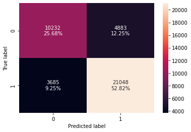

```python
# creating confusion matrix
confusion_matrix_statsmodels(lg, X_train, y_train)
```

```python
log_reg_model_train_perf = model_performance_classification_statsmodels(
    lg, X_train, y_train
)

print("Training performance:")
log_reg_model_train_perf
```

```
Training performance:
```

|  | Accuracy | Recall | Precision | F1 |
| --- | --- | --- | --- | --- |
| 0 | 0.784983 | 0.851009 | 0.811693 | 0.830886 |

### ROC-AUC

- ROC-AUC on training set

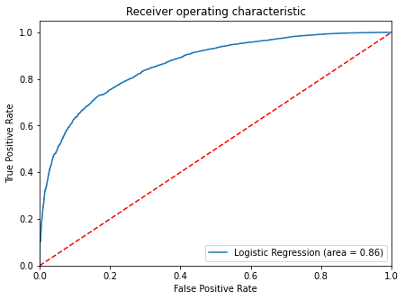

```python
logit_roc_auc_train = roc_auc_score(y_train, lg.predict(X_train))
fpr, tpr, thresholds = roc_curve(y_train, lg.predict(X_train))
plt.figure(figsize=(7, 5))
plt.plot(fpr, tpr, label="Logistic Regression (area = %0.2f)" % logit_roc_auc_train)
plt.plot([0, 1], [0, 1], "r--")
plt.xlim([0.0, 1.0])
plt.ylim([0.0, 1.05])
plt.xlabel("False Positive Rate")
plt.ylabel("True Positive Rate")
plt.title("Receiver operating characteristic")
plt.legend(loc="lower right")
plt.show()
```

- Logistic Regression model is giving a good performance on training set.

## Model Performance Improvement

- Let's see if the f1 score can be improved further, by changing the model threshold using AUC-ROC Curve.

```python
# Optimal threshold as per AUC-ROC curve
# The optimal cut off would be where tpr is high and fpr is low
fpr, tpr, thresholds = roc_curve(y_train, lg.predict(X_train))

optimal_idx = np.argmax(tpr - fpr)
optimal_threshold_auc_roc = thresholds[optimal_idx]
print(optimal_threshold_auc_roc)
```

```
0.6852948313820593
```

- Checking model performance on training set

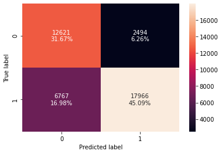

```python
# creating confusion matrix
confusion_matrix_statsmodels(lg, X_train, y_train, threshold=optimal_threshold_auc_roc)
```

```python
# checking model performance for this model
log_reg_model_train_perf_threshold_auc_roc = (
    model_performance_classification_statsmodels(
        lg, X_train, y_train, threshold=optimal_threshold_auc_roc
    )
)
print("Training performance:")
log_reg_model_train_perf_threshold_auc_roc
```

```
Training performance:
```

|  | Accuracy | Recall | Precision | F1 |
| --- | --- | --- | --- | --- |
| 0 | 0.767592 | 0.726398 | 0.878104 | 0.795079 |

- Precision of model has increased but the other metrics have reduced.
- The model is still giving a good performance.
- Let's use Precision-Recall curve and see if we can find a better threshold

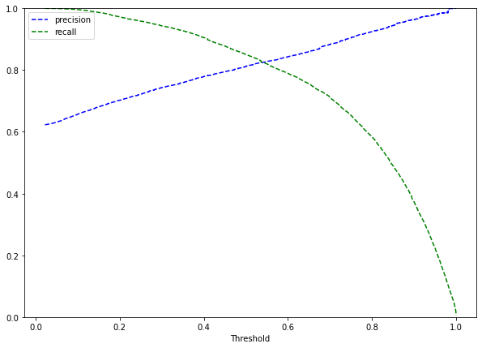

```python
y_scores = lg.predict(X_train)
prec, rec, tre = precision_recall_curve(
    y_train,
    y_scores,
)


def plot_prec_recall_vs_tresh(precisions, recalls, thresholds):
    plt.plot(thresholds, precisions[:-1], "b--", label="precision")
    plt.plot(thresholds, recalls[:-1], "g--", label="recall")
    plt.xlabel("Threshold")
    plt.legend(loc="upper left")
    plt.ylim([0, 1])


plt.figure(figsize=(10, 7))
plot_prec_recall_vs_tresh(prec, rec, tre)
plt.show()
```

```python
optimal_idx2 = np.where(prec - rec == 0)
optimal_threshold_prec_rec = tre[optimal_idx2]
print(optimal_threshold_prec_rec)
```

```
[]
```

- With above check to see,there does not seem to any other best optimal threshold
- 0.6852948313820593 is the best optimal threshold where tpr and fpr fit the best

```python
log_reg_model_train_perf_threshold_curve = model_performance_classification_statsmodels(
    lg, X_train, y_train, threshold=optimal_threshold_curve
)
print("Training performance:")
log_reg_model_train_perf_threshold_curve
```

```
Training performance:
```

|  | Accuracy | Recall | Precision | F1 |
| --- | --- | --- | --- | --- |
| 0 | 0.767617 | 0.726438 | 0.87811 | 0.795106 |

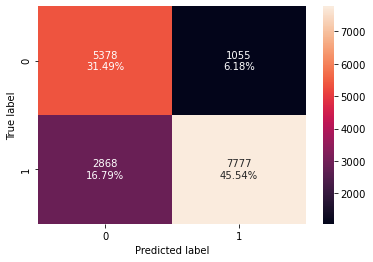

```python
# creating confusion matrix
confusion_matrix_statsmodels(lg, X_test, y_test, threshold=optimal_threshold_curve)
```

```python
log_reg_model_test_perf_threshold_curve = model_performance_classification_statsmodels(
    lg, X_test, y_test, threshold=optimal_threshold_curve
)
print("Test performance:")
log_reg_model_test_perf_threshold_curve
```

```
Test performance:
```

|  | Accuracy | Recall | Precision | F1 |
| --- | --- | --- | --- | --- |
| 0 | 0.770289 | 0.730578 | 0.880548 | 0.798583 |

### Model performance summary

```python
# training performance comparison

models_train_comp_df = pd.concat(
    [
        log_reg_model_train_perf.T,
        log_reg_model_train_perf_threshold_auc_roc.T,
        log_reg_model_train_perf_threshold_curve.T,
    ],
    axis=1,
)
models_train_comp_df.columns = [
    "Logistic Regression sklearn",
    "Logistic Regression-0.68 AUC",
    "Logistic Regression-0.68 Threshold Curve",
]

print("Training performance comparison:")
models_train_comp_df
```

```
Training performance comparison:
```

|  | Logistic Regression sklearn | Logistic Regression-0.68 AUC | Logistic Regression-0.68 Threshold Curve |
| --- | --- | --- | --- |
| Accuracy | 0.784983 | 0.767592 | 0.767617 |
| Recall | 0.851009 | 0.726398 | 0.726438 |
| Precision | 0.811693 | 0.878104 | 0.878110 |
| F1 | 0.830886 | 0.795079 | 0.795106 |